# CP 6 BMW vs Volkswagen

German de los Mozos

28/11/2020

Esta práctica va a tratar de analizar la relación existente entre BMW y Volkswagen. Para ello, se van a obtener, con la ayuda de la librería “Quantmod” de R, datos sobre los precios de ambas empresas, recogidos en el portal de Yahoo Finance. El periodo considerado es el de Enero de 2014 hasta Octubre de 2020. El objetivo principal será el planteamiento de un modelo GARCH y un modelo VAR entre los dos activos.

En primer lugar, obtenemos los rendimientos de ambos activos y los presentamos en un gráfica conjunta con la evolución del precio durante el periodo estimado.

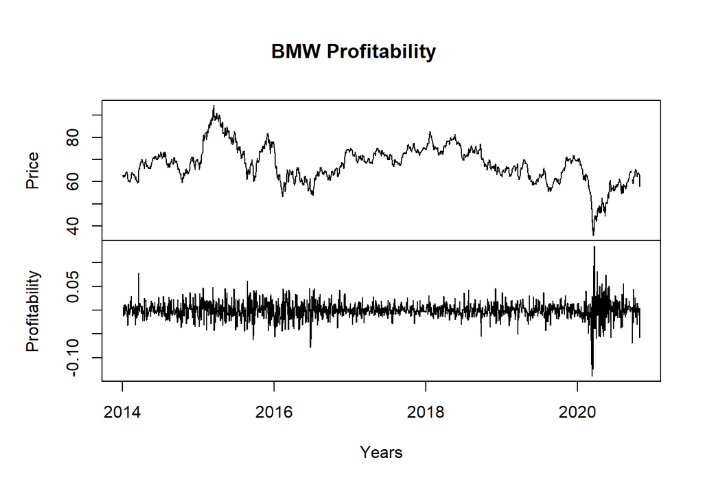

```r
# Plotting returns and stock value of each company

plot.zoo(cbind(BMWDat, dRentBMW),
         main = " BMW Profitability",
         xlab = "Years",
         ylab = c("Price","Profitability"))
```

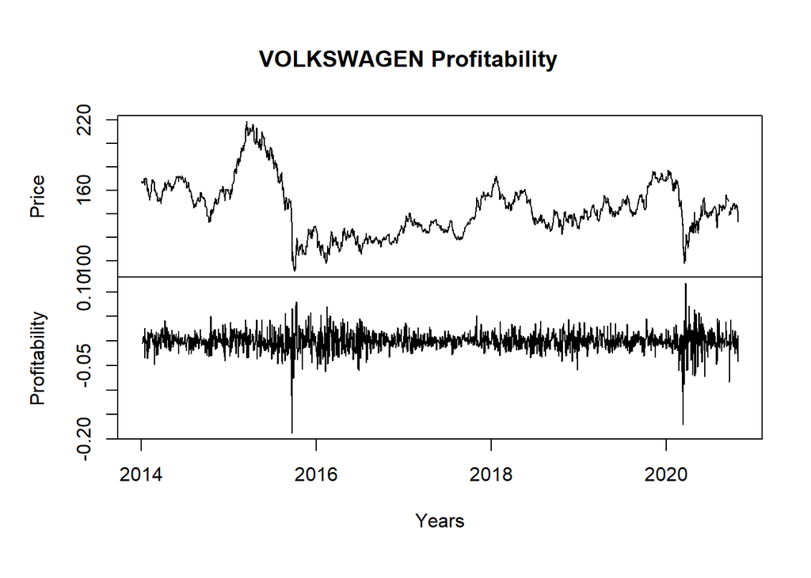

```r
plot.zoo(cbind(VOWDat, dRentVOW),
         main = " VOLKSWAGEN Profitability",
         xlab = "Years",
         ylab = c("Price","Profitability"))
```

En los gráficos representados podemos ver claramente el efecto del “Dieselgate”, en Septiembre de 2015, cuando se produjo el escándalo de emisiones contaminantes de vehículos Volskwagen. Este fue un impacto muy negativo para Volkswagen. Y, por supuesto, es notable el “shock” originado por el Covid en Marzo de este año en los precios y las rentabilidades de ambas empresas.

### Modelo GARCH

A continuación, vamos a plantear un modelo GARCH. Estos modelos se emplean en series temporales y tratan de analizar la varianza de las mismas, dado que esta, junto con la desviación típica (la volatilidad de las acciones), no son constantes. Por ello, a través de modelos como el GARCH, podemos predecir los valores futuros de la volatilidad de los rendimientos de activos.

Como primer paso, vamos a representar los rendimientos al cuadrado.

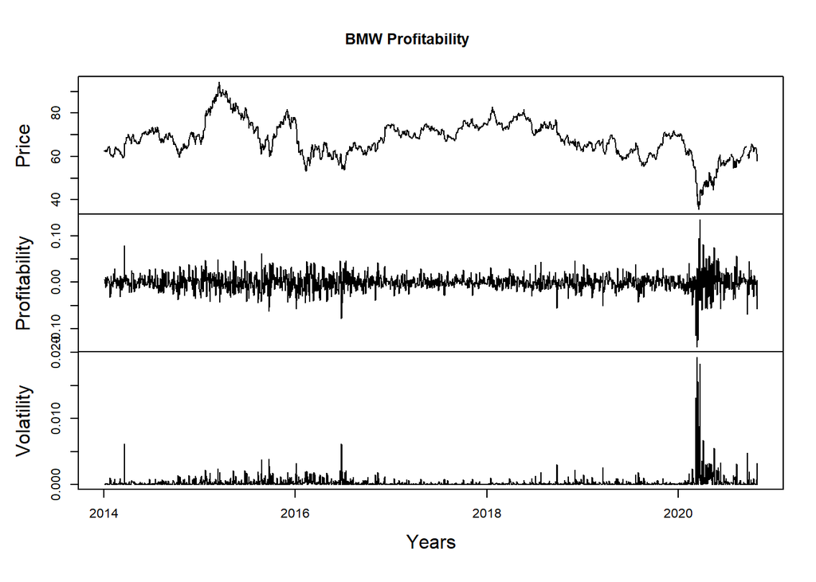

```r
# Plotting a proxy of volatility of both firms, along with the stock prices and the returns

plot.zoo(cbind(BMWDat, dRentBMW, dRentBMW^2), main = "BMW Profitability", xlab = "Years", ylab = c("Price","Profitability","Volatility"))
```

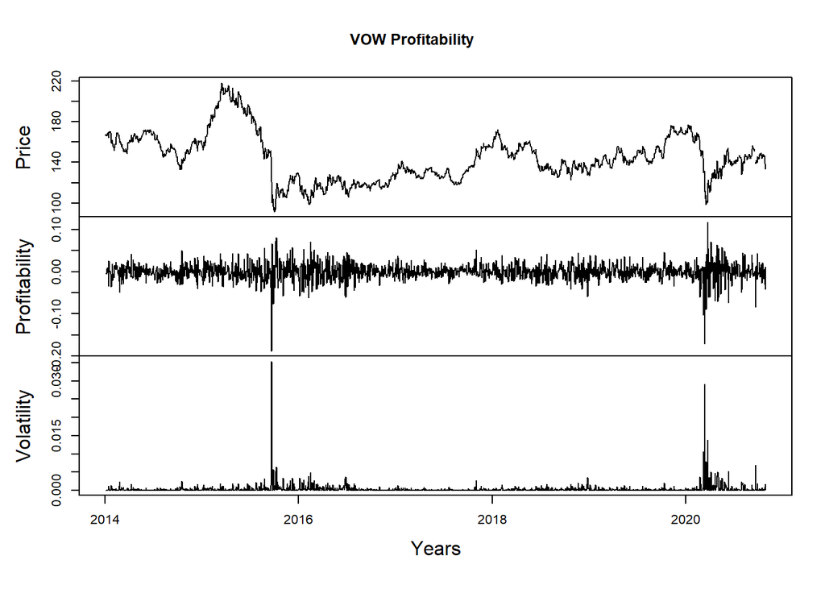

```r
plot.zoo(cbind(VOWDat, dRentVOW, dRentVOW^2), main = "VOW Profitability", xlab = "Years", ylab = c("Price","Profitability","Volatility"))
```

El siguiente paso es analizar el ACF y PACF de los retornos al cuadrado.

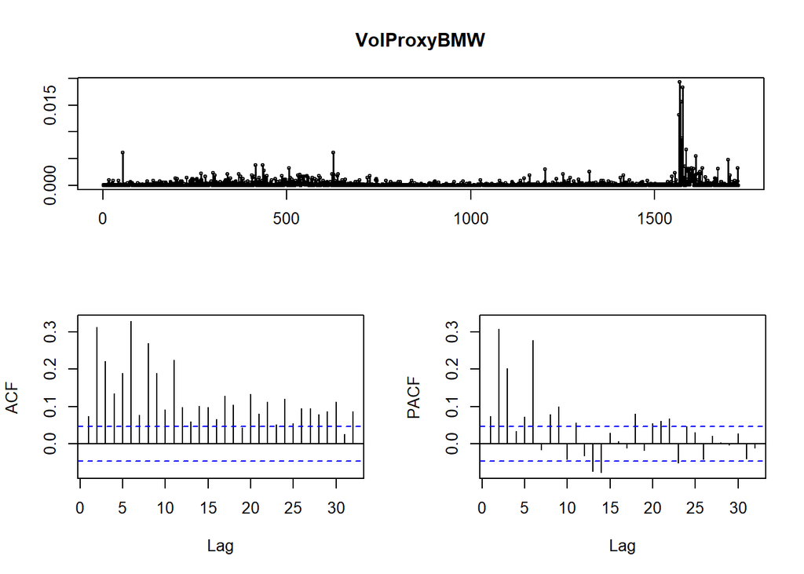

```r
# Save the squared returns in new objects

VolProxyBMW = dRentBMW^2
VolProxyVOW = dRentVOW^2

# ACF y PACF - Plot the volatilities

tsdisplay(VolProxyBMW)
```

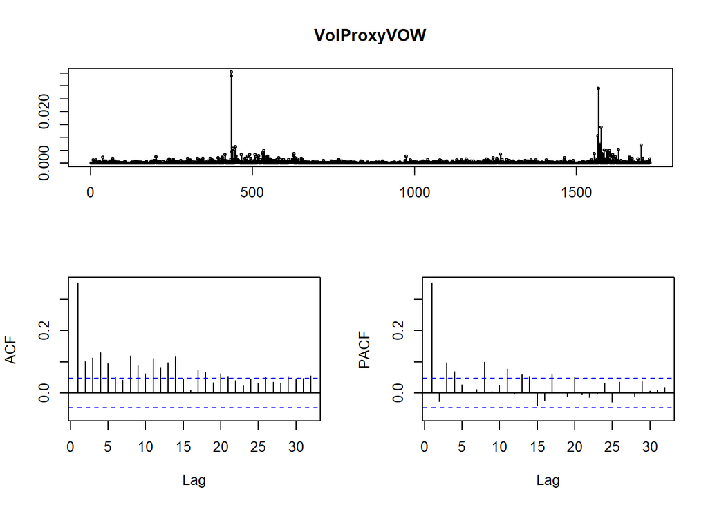

```r
tsdisplay(VolProxyVOW)
```

Visualmente podemos ver que la volatilidad de los rendimientos de los activos no es constante, como era de esperar. Adicionalmente, vamos a comprobar este hecho con los test de Ljung-Box.

```r
Box.test(VolProxyBMW,lag=10,  type="Lj")
```

```
##
##  Box-Ljung test
##
## data:  VolProxyBMW
## X-squared = 759.15, df = 10, p-value < 2.2e-16
```

```r
Box.test(VolProxyBMW,lag=20,  type="Lj")
```

```
##
##  Box-Ljung test
##
## data:  VolProxyBMW
## X-squared = 995.21, df = 20, p-value < 2.2e-16
```

```r
Box.test(VolProxyBMW,lag=40,  type="Lj")
```

```
##
##  Box-Ljung test
##
## data:  VolProxyBMW
## X-squared = 1232, df = 40, p-value < 2.2e-16
```

```r
Box.test(VolProxyVOW,lag=10,  type="Lj")
```

```
##
##  Box-Ljung test
##
## data:  VolProxyVOW
## X-squared = 351.93, df = 10, p-value < 2.2e-16
```

```r
Box.test(VolProxyVOW,lag=20,  type="Lj")
```

```
##
##  Box-Ljung test
##
## data:  VolProxyVOW
## X-squared = 455.24, df = 20, p-value < 2.2e-16
```

```r
Box.test(VolProxyVOW,lag=40,  type="Lj")
```

```
##
##  Box-Ljung test
##
## data:  VolProxyVOW
## X-squared = 510.3, df = 40, p-value < 2.2e-16
```

A continuación, llevamos a cabo el test de Lagrange, donde la hipótesis nula, indica que no habría GARCH

```r
# LM test
archTest(dRentBMW,10)
```

```
##
## Call:
## lm(formula = atsq ~ x)
##
## Residuals:
##        Min         1Q     Median         3Q        Max
## -0.0053882 -0.0002061 -0.0001069  0.0000347  0.0178274
##
## Coefficients:
##               Estimate Std. Error t value Pr(>|t|)
## (Intercept)  9.171e-05  2.469e-05   3.714 0.000210 ***
## x1          -3.855e-02  2.418e-02  -1.594 0.111060
## x2           2.491e-01  2.417e-02  10.306  < 2e-16 ***
## x3           9.727e-02  2.482e-02   3.919 9.24e-05 ***
## x4          -3.353e-02  2.492e-02  -1.345 0.178655
## x5           7.833e-02  2.422e-02   3.234 0.001245 **
## x6           2.442e-01  2.422e-02  10.082  < 2e-16 ***
## x7          -3.422e-02  2.492e-02  -1.373 0.169827
## x8           9.157e-02  2.483e-02   3.688 0.000233 ***
## x9           9.828e-02  2.418e-02   4.065 5.03e-05 ***
## x10         -4.151e-02  2.428e-02  -1.710 0.087440 .
## ---
## Signif. codes:  0 '***' 0.001 '**' 0.01 '*' 0.05 '.' 0.1 ' ' 1
##
## Residual standard error: 0.0008795 on 1707 degrees of freedom
## Multiple R-squared:  0.2239, Adjusted R-squared:  0.2194
## F-statistic: 49.25 on 10 and 1707 DF,  p-value: < 2.2e-16
```

```r
archTest(dRentVOW,10)
```

```
##
## Call:
## lm(formula = atsq ~ x)
##
## Residuals:
##       Min        1Q    Median        3Q       Max
## -0.010929 -0.000275 -0.000182  0.000025  0.034559
##
## Coefficients:
##               Estimate Std. Error t value Pr(>|t|)
## (Intercept)  1.922e-04  4.004e-05   4.801 1.72e-06 ***
## x1           3.542e-01  2.420e-02  14.636  < 2e-16 ***
## x2          -6.222e-02  2.568e-02  -2.423  0.01549 *
## x3           7.172e-02  2.560e-02   2.801  0.00515 **
## x4           5.223e-02  2.566e-02   2.036  0.04191 *
## x5           1.907e-02  2.569e-02   0.742  0.45801
## x6           2.709e-04  2.569e-02   0.011  0.99159
## x7          -2.444e-02  2.566e-02  -0.953  0.34097
## x8           1.002e-01  2.560e-02   3.914 9.42e-05 ***
## x9          -4.316e-03  2.567e-02  -0.168  0.86653
## x10          2.535e-02  2.420e-02   1.047  0.29509
## ---
## Signif. codes:  0 '***' 0.001 '**' 0.01 '*' 0.05 '.' 0.1 ' ' 1
##
## Residual standard error: 0.00146 on 1707 degrees of freedom
## Multiple R-squared:  0.1475, Adjusted R-squared:  0.1425
## F-statistic: 29.53 on 10 and 1707 DF,  p-value: < 2.2e-16
```

Procedemos ahora con el ajuste de los modelos. Construimos primero un ARCH(1)

```r
BMWarch = garchFit(~1 + garch(1,0),data = dRentBMW, trace = F)
summary(BMWarch)
```

```
##
## Title:
##  GARCH Modelling
##
## Call:
##  garchFit(formula = ~1 + garch(1, 0), data = dRentBMW, trace = F)
##
## Mean and Variance Equation:
##  data ~ 1 + garch(1, 0)
## <environment: 0x00000000133475a0>
##  [data = dRentBMW]
##
## Conditional Distribution:
##  norm
##
## Coefficient(s):
##         mu       omega      alpha1
## 2.1908e-05  2.2793e-04  3.1802e-01
##
## Std. Errors:
##  based on Hessian
##
## Error Analysis:
##         Estimate  Std. Error  t value Pr(>|t|)
## mu     2.191e-05   3.911e-04    0.056    0.955
## omega  2.279e-04   1.030e-05   22.126  < 2e-16 ***
## alpha1 3.180e-01   4.541e-02    7.004 2.49e-12 ***
## ---
## Signif. codes:  0 '***' 0.001 '**' 0.01 '*' 0.05 '.' 0.1 ' ' 1
##
## Log Likelihood:
##  4581.306    normalized:  2.651219
##
## Description:
##  Mon Nov 30 18:27:25 2020 by user: German de los Mozos
##
##
## Standardised Residuals Tests:
##                                 Statistic p-Value
##  Jarque-Bera Test   R    Chi^2  3868.766  0
##  Shapiro-Wilk Test  R    W      0.9369562 0
##  Ljung-Box Test     R    Q(10)  20.96566  0.0213343
##  Ljung-Box Test     R    Q(15)  28.91217  0.01650863
##  Ljung-Box Test     R    Q(20)  33.98949  0.02619589
##  Ljung-Box Test     R^2  Q(10)  316.948   0
##  Ljung-Box Test     R^2  Q(15)  380.9459  0
##  Ljung-Box Test     R^2  Q(20)  473.9984  0
##  LM Arch Test       R    TR^2   231.5013  0
##
## Information Criterion Statistics:
##       AIC       BIC       SIC      HQIC
## -5.298965 -5.289495 -5.298971 -5.295462
```

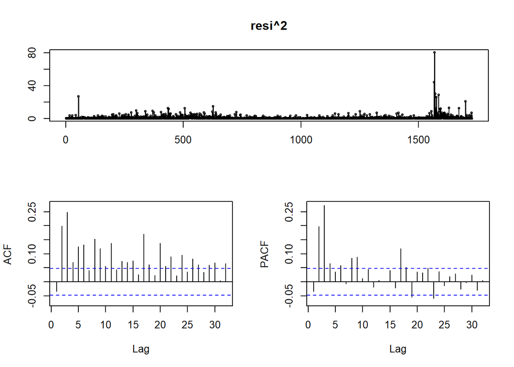

```r
resi = residuals(BMWarch, standardize = T) # residuals
resi = xts(resi,order.by = index(dRentBMW)) # residuals as xts
tsdisplay(resi^2) # acf pacf residuals
```

```r
VOWarch = garchFit(~1 + garch(1,0),data = dRentVOW, trace = F)
summary(VOWarch)
```

```
##
## Title:
##  GARCH Modelling
##
## Call:
##  garchFit(formula = ~1 + garch(1, 0), data = dRentVOW, trace = F)
##
## Mean and Variance Equation:
##  data ~ 1 + garch(1, 0)
## <environment: 0x000000001fe8ecd0>
##  [data = dRentVOW]
##
## Conditional Distribution:
##  norm
##
## Coefficient(s):
##         mu       omega      alpha1
## 1.4353e-05  2.9319e-04  2.8422e-01
##
## Std. Errors:
##  based on Hessian
##
## Error Analysis:
##         Estimate  Std. Error  t value Pr(>|t|)
## mu     1.435e-05   4.433e-04    0.032    0.974
## omega  2.932e-04   1.303e-05   22.504  < 2e-16 ***
## alpha1 2.842e-01   4.144e-02    6.858 6.98e-12 ***
## ---
## Signif. codes:  0 '***' 0.001 '**' 0.01 '*' 0.05 '.' 0.1 ' ' 1
##
## Log Likelihood:
##  4379.367    normalized:  2.534356
##
## Description:
##  Mon Nov 30 18:27:25 2020 by user: German de los Mozos
##
##
## Standardised Residuals Tests:
##                                 Statistic p-Value
##  Jarque-Bera Test   R    Chi^2  6792.424  0
##  Shapiro-Wilk Test  R    W      0.9349709 0
##  Ljung-Box Test     R    Q(10)  21.15546  0.02003525
##  Ljung-Box Test     R    Q(15)  24.41962  0.05830166
##  Ljung-Box Test     R    Q(20)  32.3566   0.03964364
##  Ljung-Box Test     R^2  Q(10)  206.1052  0
##  Ljung-Box Test     R^2  Q(15)  258.1284  0
##  Ljung-Box Test     R^2  Q(20)  292.158   0
##  LM Arch Test       R    TR^2   163.8959  0
##
## Information Criterion Statistics:
##       AIC       BIC       SIC      HQIC
## -5.065239 -5.055769 -5.065245 -5.061736
```

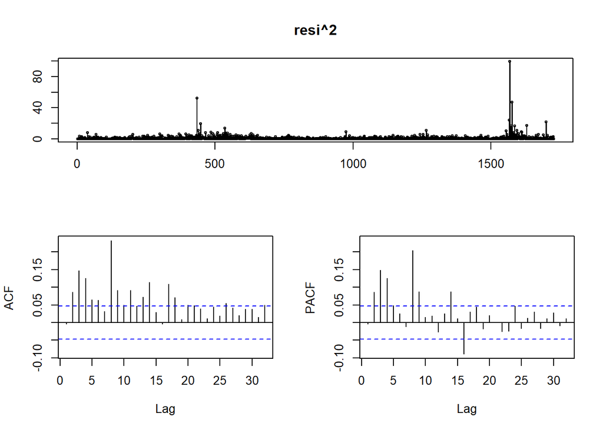

```r
resi = residuals(VOWarch, standardize = T) # residuals
resi = xts(resi,order.by = index(dRentVOW)) # residuals as xts
tsdisplay(resi^2) # acf pacf residuals
```

El siguiente modelo es el GARCH(1,1)

```r
BMWgarch = fGarch::garchFit(~1 + garch(1,1), data = dRentBMW, trace = F)
summary(BMWgarch)
```

```
##
## Title:
##  GARCH Modelling
##
## Call:
##  fGarch::garchFit(formula = ~1 + garch(1, 1), data = dRentBMW,
##     trace = F)
##
## Mean and Variance Equation:
##  data ~ 1 + garch(1, 1)
## <environment: 0x000000001c70f0c0>
##  [data = dRentBMW]
##
## Conditional Distribution:
##  norm
##
## Coefficient(s):
##         mu       omega      alpha1       beta1
## 2.4480e-04  2.5322e-06  4.9566e-02  9.4275e-01
##
## Std. Errors:
##  based on Hessian
##
## Error Analysis:
##         Estimate  Std. Error  t value Pr(>|t|)
## mu     2.448e-04   3.368e-04    0.727  0.46728
## omega  2.532e-06   9.759e-07    2.595  0.00947 **
## alpha1 4.957e-02   7.941e-03    6.242 4.32e-10 ***
## beta1  9.427e-01   9.457e-03   99.689  < 2e-16 ***
## ---
## Signif. codes:  0 '***' 0.001 '**' 0.01 '*' 0.05 '.' 0.1 ' ' 1
##
## Log Likelihood:
##  4751.161    normalized:  2.749514
##
## Description:
##  Mon Nov 30 18:27:26 2020 by user: German de los Mozos
##
##
## Standardised Residuals Tests:
##                                 Statistic p-Value
##  Jarque-Bera Test   R    Chi^2  763.5816  0
##  Shapiro-Wilk Test  R    W      0.9719484 0
##  Ljung-Box Test     R    Q(10)  21.22249  0.01959442
##  Ljung-Box Test     R    Q(15)  25.44835  0.04423666
##  Ljung-Box Test     R    Q(20)  31.26611  0.05177399
##  Ljung-Box Test     R^2  Q(10)  22.55164  0.01252817
##  Ljung-Box Test     R^2  Q(15)  23.89845  0.06683815
##  Ljung-Box Test     R^2  Q(20)  27.35404  0.125594
##  LM Arch Test       R    TR^2   23.40251  0.02449674
##
## Information Criterion Statistics:
##       AIC       BIC       SIC      HQIC
## -5.494399 -5.481772 -5.494410 -5.489728
```

```r
resi=residuals(BMWgarch,standardize=T) # residuals
```

Ahora vamos a ajustar el modelo GARCH, pero utilizando la distribución de t student.

```r
BMWstd = garchFit(~1 + garch(1,1), data = dRentBMW, trace = F, cond.dist = "std")
summary(BMWstd)
```

```
##
## Title:
##  GARCH Modelling
##
## Call:
##  garchFit(formula = ~1 + garch(1, 1), data = dRentBMW, cond.dist = "std",
##     trace = F)
##
## Mean and Variance Equation:
##  data ~ 1 + garch(1, 1)
## <environment: 0x000000001fcb46e8>
##  [data = dRentBMW]
##
## Conditional Distribution:
##  std
##
## Coefficient(s):
##          mu        omega       alpha1        beta1        shape
## -4.1960e-05   2.0572e-06   4.6600e-02   9.4830e-01   4.9763e+00
##
## Std. Errors:
##  based on Hessian
##
## Error Analysis:
##          Estimate  Std. Error  t value Pr(>|t|)
## mu     -4.196e-05   3.090e-04   -0.136   0.8920
## omega   2.057e-06   9.588e-07    2.146   0.0319 *
## alpha1  4.660e-02   9.794e-03    4.758 1.96e-06 ***
## beta1   9.483e-01   1.033e-02   91.845  < 2e-16 ***
## shape   4.976e+00   6.083e-01    8.181 2.22e-16 ***
## ---
## Signif. codes:  0 '***' 0.001 '**' 0.01 '*' 0.05 '.' 0.1 ' ' 1
##
## Log Likelihood:
##  4822.855    normalized:  2.791004
##
## Description:
##  Mon Nov 30 18:27:27 2020 by user: German de los Mozos
##
##
## Standardised Residuals Tests:
##                                 Statistic p-Value
##  Jarque-Bera Test   R    Chi^2  794.1946  0
##  Shapiro-Wilk Test  R    W      0.9715777 0
##  Ljung-Box Test     R    Q(10)  21.42503  0.0183172
##  Ljung-Box Test     R    Q(15)  25.58087  0.04266584
##  Ljung-Box Test     R    Q(20)  31.41152  0.04998681
##  Ljung-Box Test     R^2  Q(10)  26.11435  0.0035894
##  Ljung-Box Test     R^2  Q(15)  27.45445  0.0252445
##  Ljung-Box Test     R^2  Q(20)  31.10622  0.05380372
##  LM Arch Test       R    TR^2   27.00332  0.007718694
##
## Information Criterion Statistics:
##       AIC       BIC       SIC      HQIC
## -5.576221 -5.560437 -5.576237 -5.570382
```

```r
VOWstd = garchFit(~1 + garch(1,1), data = dRentVOW, trace = F, cond.dist = "std")
summary(VOWstd)
```

```
##
## Title:
##  GARCH Modelling
##
## Call:
##  garchFit(formula = ~1 + garch(1, 1), data = dRentVOW, cond.dist = "std",
##     trace = F)
##
## Mean and Variance Equation:
##  data ~ 1 + garch(1, 1)
## <environment: 0x00000000152bef20>
##  [data = dRentVOW]
##
## Conditional Distribution:
##  std
##
## Coefficient(s):
##         mu       omega      alpha1       beta1       shape
## 2.1306e-04  5.2780e-06  6.6153e-02  9.1965e-01  6.5506e+00
##
## Std. Errors:
##  based on Hessian
##
## Error Analysis:
##         Estimate  Std. Error  t value Pr(>|t|)
## mu     2.131e-04   3.583e-04    0.595  0.55208
## omega  5.278e-06   1.983e-06    2.661  0.00779 **
## alpha1 6.615e-02   1.413e-02    4.682 2.84e-06 ***
## beta1  9.197e-01   1.605e-02   57.292  < 2e-16 ***
## shape  6.551e+00   9.753e-01    6.717 1.86e-11 ***
## ---
## Signif. codes:  0 '***' 0.001 '**' 0.01 '*' 0.05 '.' 0.1 ' ' 1
##
## Log Likelihood:
##  4593.485    normalized:  2.658267
##
## Description:
##  Mon Nov 30 18:27:27 2020 by user: German de los Mozos
##
##
## Standardised Residuals Tests:
##                                 Statistic p-Value
##  Jarque-Bera Test   R    Chi^2  1624.571  0
##  Shapiro-Wilk Test  R    W      0.9694467 0
##  Ljung-Box Test     R    Q(10)  17.38045  0.06635821
##  Ljung-Box Test     R    Q(15)  18.95754  0.2156642
##  Ljung-Box Test     R    Q(20)  19.53789  0.4871497
##  Ljung-Box Test     R^2  Q(10)  20.99805  0.02110716
##  Ljung-Box Test     R^2  Q(15)  22.48754  0.0956431
##  Ljung-Box Test     R^2  Q(20)  25.09456  0.1978372
##  LM Arch Test       R    TR^2   22.97353  0.02795147
##
## Information Criterion Statistics:
##       AIC       BIC       SIC      HQIC
## -5.310746 -5.294963 -5.310763 -5.304908
```

Como último paso, hacemos las predicciones.

```r
predict(BMWstd) #forecast volatility
```

```
##     meanForecast  meanError standardDeviation
## 1  -4.196021e-05 0.02052098        0.02052098
## 2  -4.196021e-05 0.02051881        0.02051881
## 3  -4.196021e-05 0.02051666        0.02051666
## 4  -4.196021e-05 0.02051452        0.02051452
## 5  -4.196021e-05 0.02051239        0.02051239
## 6  -4.196021e-05 0.02051028        0.02051028
## 7  -4.196021e-05 0.02050817        0.02050817
## 8  -4.196021e-05 0.02050607        0.02050607
## 9  -4.196021e-05 0.02050398        0.02050398
## 10 -4.196021e-05 0.02050190        0.02050190
```

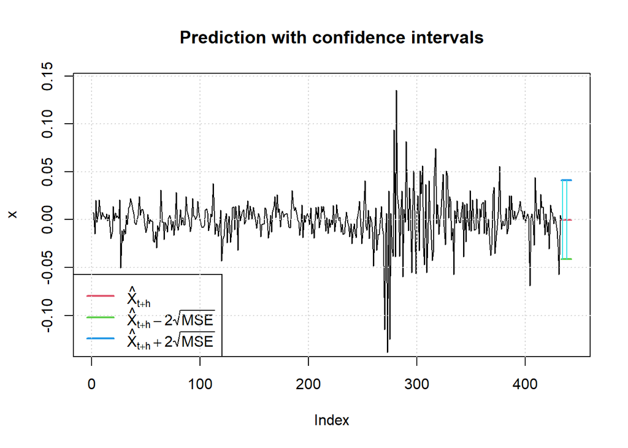

```
##     meanForecast  meanError standardDeviation lowerInterval upperInterval
## 1  -4.196021e-05 0.02052098        0.02052098   -0.04108391    0.04099999
## 2  -4.196021e-05 0.02051881        0.02051881   -0.04107959    0.04099567
## 3  -4.196021e-05 0.02051666        0.02051666   -0.04107529    0.04099137
## 4  -4.196021e-05 0.02051452        0.02051452   -0.04107101    0.04098709
## 5  -4.196021e-05 0.02051239        0.02051239   -0.04106675    0.04098283
## 6  -4.196021e-05 0.02051028        0.02051028   -0.04106251    0.04097859
## 7  -4.196021e-05 0.02050817        0.02050817   -0.04105829    0.04097437
## 8  -4.196021e-05 0.02050607        0.02050607   -0.04105410    0.04097018
## 9  -4.196021e-05 0.02050398        0.02050398   -0.04104992    0.04096600
## 10 -4.196021e-05 0.02050190        0.02050190   -0.04104577    0.04096185
```

```r
predict(BMWstd, n.ahead = 10, plot=TRUE, crit_val=2) # plot with 2*standard error
```

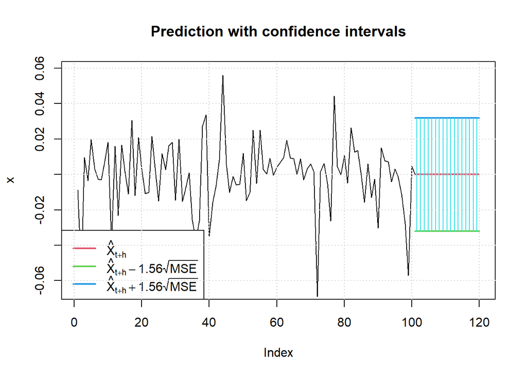

```
##     meanForecast  meanError standardDeviation lowerInterval upperInterval
## 1  -4.196021e-05 0.02052098        0.02052098   -0.03205488    0.03197096
## 2  -4.196021e-05 0.02051881        0.02051881   -0.03205151    0.03196759
## 3  -4.196021e-05 0.02051666        0.02051666   -0.03204816    0.03196423
## 4  -4.196021e-05 0.02051452        0.02051452   -0.03204482    0.03196090
## 5  -4.196021e-05 0.02051239        0.02051239   -0.03204149    0.03195757
## 6  -4.196021e-05 0.02051028        0.02051028   -0.03203819    0.03195427
## 7  -4.196021e-05 0.02050817        0.02050817   -0.03203490    0.03195098
## 8  -4.196021e-05 0.02050607        0.02050607   -0.03203163    0.03194771
## 9  -4.196021e-05 0.02050398        0.02050398   -0.03202837    0.03194445
## 10 -4.196021e-05 0.02050190        0.02050190   -0.03202513    0.03194121
## 11 -4.196021e-05 0.02049984        0.02049984   -0.03202191    0.03193799
## 12 -4.196021e-05 0.02049778        0.02049778   -0.03201870    0.03193478
## 13 -4.196021e-05 0.02049574        0.02049574   -0.03201551    0.03193159
## 14 -4.196021e-05 0.02049370        0.02049370   -0.03201233    0.03192841
## 15 -4.196021e-05 0.02049168        0.02049168   -0.03200917    0.03192525
## 16 -4.196021e-05 0.02048966        0.02048966   -0.03200603    0.03192211
## 17 -4.196021e-05 0.02048765        0.02048765   -0.03200290    0.03191898
## 18 -4.196021e-05 0.02048566        0.02048566   -0.03199979    0.03191587
## 19 -4.196021e-05 0.02048367        0.02048367   -0.03199669    0.03191277
## 20 -4.196021e-05 0.02048170        0.02048170   -0.03199361    0.03190969
```

```r
predict(BMWstd,n.ahead=20,plot=TRUE,conf=.9,nx=100) # plot 100 data with 90% confidence
```

```r
predict(VOWstd) #forecast volatility
```

```
##    meanForecast  meanError standardDeviation
## 1  0.0002130554 0.02041284        0.02041284
## 2  0.0002130554 0.02039724        0.02039724
## 3  0.0002130554 0.02038186        0.02038186
## 4  0.0002130554 0.02036668        0.02036668
## 5  0.0002130554 0.02035171        0.02035171
## 6  0.0002130554 0.02033693        0.02033693
## 7  0.0002130554 0.02032236        0.02032236
## 8  0.0002130554 0.02030798        0.02030798
## 9  0.0002130554 0.02029380        0.02029380
## 10 0.0002130554 0.02027981        0.02027981
```

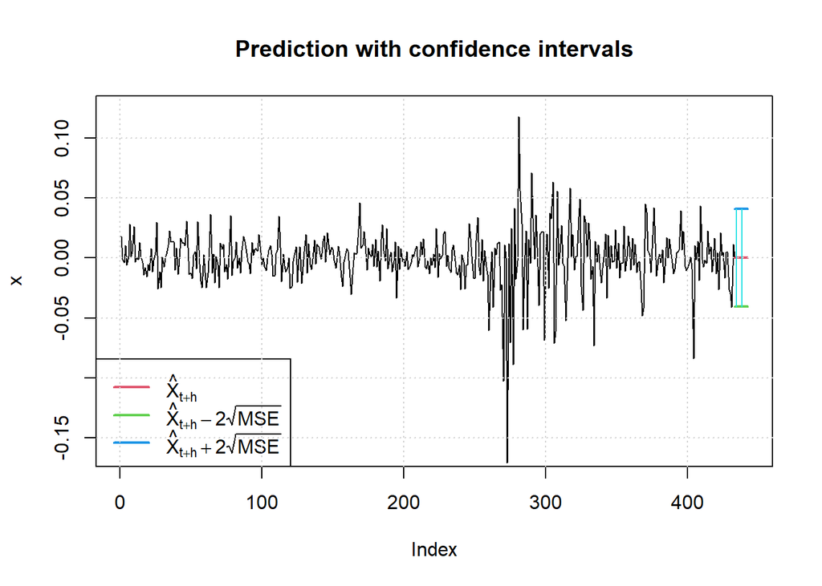

```
##    meanForecast  meanError standardDeviation lowerInterval upperInterval
## 1  0.0002130554 0.02041284        0.02041284   -0.04061263    0.04103874
## 2  0.0002130554 0.02039724        0.02039724   -0.04058143    0.04100754
## 3  0.0002130554 0.02038186        0.02038186   -0.04055066    0.04097677
## 4  0.0002130554 0.02036668        0.02036668   -0.04052030    0.04094642
## 5  0.0002130554 0.02035171        0.02035171   -0.04049036    0.04091647
## 6  0.0002130554 0.02033693        0.02033693   -0.04046081    0.04088692
## 7  0.0002130554 0.02032236        0.02032236   -0.04043166    0.04085777
## 8  0.0002130554 0.02030798        0.02030798   -0.04040291    0.04082902
## 9  0.0002130554 0.02029380        0.02029380   -0.04037454    0.04080065
## 10 0.0002130554 0.02027981        0.02027981   -0.04034656    0.04077267
```

```r
predict(VOWstd, n.ahead = 10, plot=TRUE, crit_val=2) # plot with 2*standard error
```

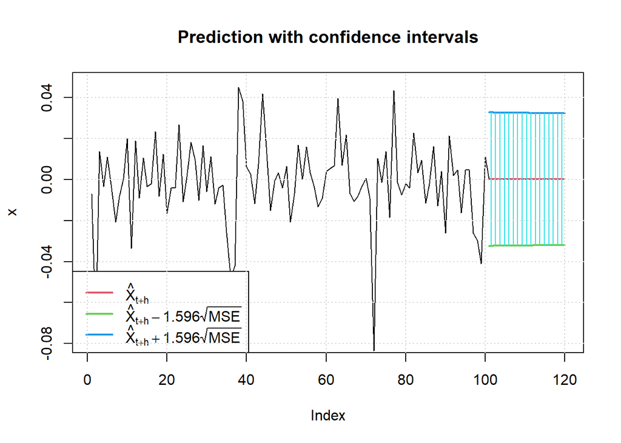

```
##    meanForecast  meanError standardDeviation lowerInterval upperInterval
## 1  0.0002130554 0.02041284        0.02041284   -0.03235644    0.03278255
## 2  0.0002130554 0.02039724        0.02039724   -0.03233155    0.03275766
## 3  0.0002130554 0.02038186        0.02038186   -0.03230700    0.03273312
## 4  0.0002130554 0.02036668        0.02036668   -0.03228279    0.03270890
## 5  0.0002130554 0.02035171        0.02035171   -0.03225889    0.03268500
## 6  0.0002130554 0.02033693        0.02033693   -0.03223532    0.03266143
## 7  0.0002130554 0.02032236        0.02032236   -0.03221207    0.03263818
## 8  0.0002130554 0.02030798        0.02030798   -0.03218913    0.03261524
## 9  0.0002130554 0.02029380        0.02029380   -0.03216650    0.03259261
## 10 0.0002130554 0.02027981        0.02027981   -0.03214418    0.03257029
## 11 0.0002130554 0.02026601        0.02026601   -0.03212216    0.03254827
## 12 0.0002130554 0.02025239        0.02025239   -0.03210043    0.03252654
## 13 0.0002130554 0.02023896        0.02023896   -0.03207900    0.03250511
## 14 0.0002130554 0.02022571        0.02022571   -0.03205786    0.03248397
## 15 0.0002130554 0.02021264        0.02021264   -0.03203701    0.03246312
## 16 0.0002130554 0.02019975        0.02019975   -0.03201644    0.03244255
## 17 0.0002130554 0.02018703        0.02018703   -0.03199615    0.03242226
## 18 0.0002130554 0.02017449        0.02017449   -0.03197613    0.03240224
## 19 0.0002130554 0.02016211        0.02016211   -0.03195639    0.03238250
## 20 0.0002130554 0.02014990        0.02014990   -0.03193691    0.03236302
```

```r
predict(VOWstd,n.ahead=20,plot=TRUE,conf=.9,nx=100) # plot 100 data with 90% confidence
```

```r
predict(BMWgarch) #forecast volatility
```

```
##    meanForecast  meanError standardDeviation
## 1  0.0002447973 0.02043890        0.02043890
## 2  0.0002447973 0.02042230        0.02042230
## 3  0.0002447973 0.02040581        0.02040581
## 4  0.0002447973 0.02038944        0.02038944
## 5  0.0002447973 0.02037318        0.02037318
## 6  0.0002447973 0.02035703        0.02035703
## 7  0.0002447973 0.02034100        0.02034100
## 8  0.0002447973 0.02032507        0.02032507
## 9  0.0002447973 0.02030926        0.02030926
## 10 0.0002447973 0.02029355        0.02029355
```

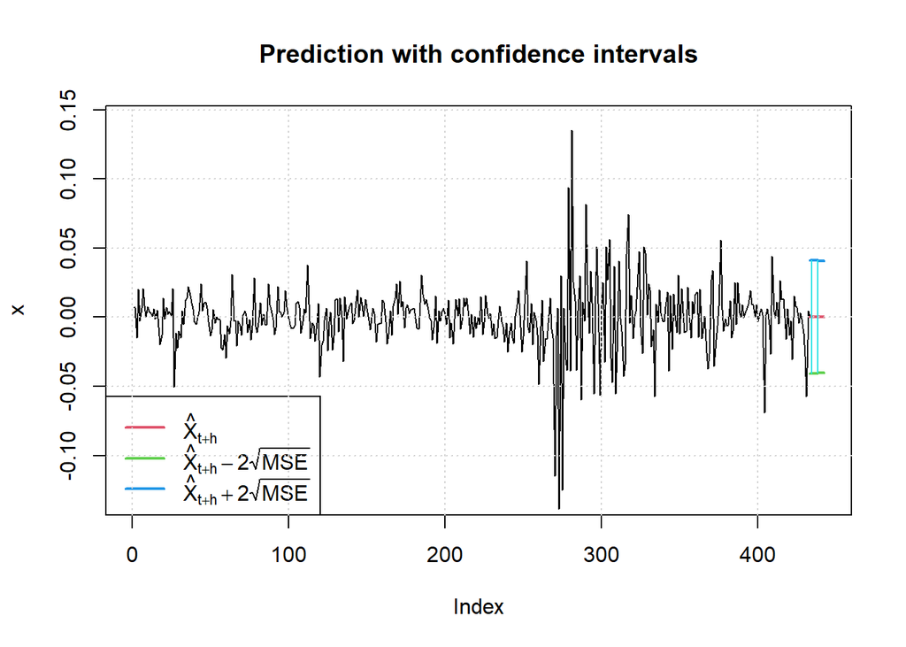

```
##    meanForecast  meanError standardDeviation lowerInterval upperInterval
## 1  0.0002447973 0.02043890        0.02043890   -0.04063299    0.04112259
## 2  0.0002447973 0.02042230        0.02042230   -0.04059979    0.04108939
## 3  0.0002447973 0.02040581        0.02040581   -0.04056682    0.04105642
## 4  0.0002447973 0.02038944        0.02038944   -0.04053408    0.04102367
## 5  0.0002447973 0.02037318        0.02037318   -0.04050156    0.04099115
## 6  0.0002447973 0.02035703        0.02035703   -0.04046927    0.04095886
## 7  0.0002447973 0.02034100        0.02034100   -0.04043719    0.04092679
## 8  0.0002447973 0.02032507        0.02032507   -0.04040535    0.04089494
## 9  0.0002447973 0.02030926        0.02030926   -0.04037372    0.04086331
## 10 0.0002447973 0.02029355        0.02029355   -0.04034230    0.04083190
```

```r
predict(BMWgarch, n.ahead = 10, plot=TRUE, crit_val=2) # plot with 2*standard error
```

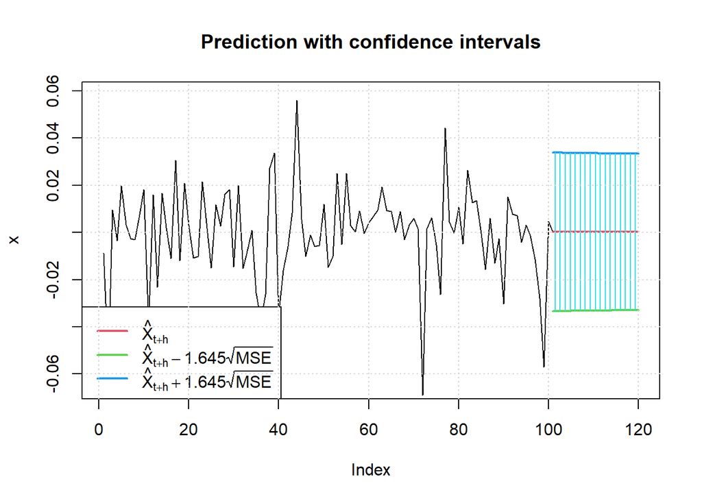

```
##    meanForecast  meanError standardDeviation lowerInterval upperInterval
## 1  0.0002447973 0.02043890        0.02043890   -0.03337419    0.03386379
## 2  0.0002447973 0.02042230        0.02042230   -0.03334689    0.03383648
## 3  0.0002447973 0.02040581        0.02040581   -0.03331977    0.03380937
## 4  0.0002447973 0.02038944        0.02038944   -0.03329284    0.03378244
## 5  0.0002447973 0.02037318        0.02037318   -0.03326610    0.03375569
## 6  0.0002447973 0.02035703        0.02035703   -0.03323954    0.03372913
## 7  0.0002447973 0.02034100        0.02034100   -0.03321316    0.03370276
## 8  0.0002447973 0.02032507        0.02032507   -0.03318697    0.03367656
## 9  0.0002447973 0.02030926        0.02030926   -0.03316096    0.03365055
## 10 0.0002447973 0.02029355        0.02029355   -0.03313512    0.03362472
## 11 0.0002447973 0.02027795        0.02027795   -0.03310947    0.03359906
## 12 0.0002447973 0.02026247        0.02026247   -0.03308399    0.03357359
## 13 0.0002447973 0.02024708        0.02024708   -0.03305869    0.03354829
## 14 0.0002447973 0.02023181        0.02023181   -0.03303357    0.03352316
## 15 0.0002447973 0.02021664        0.02021664   -0.03300862    0.03349821
## 16 0.0002447973 0.02020158        0.02020158   -0.03298384    0.03347343
## 17 0.0002447973 0.02018662        0.02018662   -0.03295923    0.03344883
## 18 0.0002447973 0.02017176        0.02017176   -0.03293480    0.03342439
## 19 0.0002447973 0.02015701        0.02015701   -0.03291054    0.03340013
## 20 0.0002447973 0.02014236        0.02014236   -0.03288644    0.03337603
```

```r
predict(BMWgarch,n.ahead=20,plot=TRUE,conf=.9,nx=100) # plot 100 data with 90% confidence
```

### Modelo VAR

En un modelo VAR todas las variables se influyen entre sí, es decir que todas las variables ahora son tratadas como endógenas. Se van a considerar tantas ecuaciones como variables se quieran incluir. EL vector autorregresivo se utiliza para estudiar la relación bidireccional entre las variables. Puesto que se aplica a series estacionarias, utilizaremos las diferencias para realizar la conversión. Además, convertimos a datos mensuales.

```r
bmw.ret <- diff(log(BMWDat))
volks.ret <- diff(log(VOWDat))
```

```r
bmw.m <- to.monthly(bmw.ret)$bmw.ret.Close
volks.m <- to.monthly(volks.ret)$volks.ret.Close
```

tilizamos el criterio del menor AIC para seleccionar el número de retardos.

```r
VARselect(auto)
```

```
## $selection
## AIC(n)  HQ(n)  SC(n) FPE(n)
##      1      1      1      1
##
## $criteria
##                    1             2             3             4             5
## AIC(n) -1.715605e+01 -1.714886e+01 -1.706600e+01 -1.706876e+01 -1.697505e+01
## HQ(n)  -1.708052e+01 -1.702298e+01 -1.688976e+01 -1.684217e+01 -1.669811e+01
## SC(n)  -1.696633e+01 -1.683266e+01 -1.662331e+01 -1.649959e+01 -1.627940e+01
## FPE(n)  3.542130e-08  3.568944e-08  3.880309e-08  3.875017e-08  4.265042e-08
##                    6             7             8             9            10
## AIC(n) -1.691906e+01 -1.687122e+01 -1.679465e+01 -1.670428e+01 -1.664429e+01
## HQ(n)  -1.659177e+01 -1.649357e+01 -1.636666e+01 -1.622593e+01 -1.611559e+01
## SC(n)  -1.609693e+01 -1.592261e+01 -1.571956e+01 -1.550270e+01 -1.531624e+01
## FPE(n)  4.525033e-08  4.767609e-08  5.176808e-08  5.708665e-08  6.118201e-08
```

Como podemos ver, utilizaremos un solo retardo.

```r
var = VAR(auto)
summary(var)
```

```
##
## VAR Estimation Results:
## =========================
## Endogenous variables: bmw.ret.Close, volks.ret.Close
## Deterministic variables: const
## Sample size: 81
## Log Likelihood: 475.879
## Roots of the characteristic polynomial:
## 0.1793 0.06825
## Call:
## VAR(y = auto)
##
##
## Estimation results for equation bmw.ret.Close:
## ==============================================
## bmw.ret.Close = bmw.ret.Close.l1 + volks.ret.Close.l1 + const
##
##                     Estimate Std. Error t value Pr(>|t|)
## bmw.ret.Close.l1   -0.104732   0.159438  -0.657    0.513
## volks.ret.Close.l1  0.037830   0.125623   0.301    0.764
## const              -0.002364   0.001571  -1.504    0.137
##
##
## Residual standard error: 0.0139 on 78 degrees of freedom
## Multiple R-Squared: 0.006164,    Adjusted R-squared: -0.01932
## F-statistic: 0.2419 on 2 and 78 DF,  p-value: 0.7857
##
##
## Estimation results for equation volks.ret.Close:
## ================================================
## volks.ret.Close = bmw.ret.Close.l1 + volks.ret.Close.l1 + const
##
##                     Estimate Std. Error t value Pr(>|t|)
## bmw.ret.Close.l1   -0.273837   0.200423  -1.366    0.176
## volks.ret.Close.l1  0.215733   0.157916   1.366    0.176
## const              -0.002773   0.001975  -1.404    0.164
##
##
## Residual standard error: 0.01747 on 78 degrees of freedom
## Multiple R-Squared: 0.0273,  Adjusted R-squared: 0.002359
## F-statistic: 1.095 on 2 and 78 DF,  p-value: 0.3398
##
##
##
## Covariance matrix of residuals:
##                 bmw.ret.Close volks.ret.Close
## bmw.ret.Close       0.0001931       0.0001726
## volks.ret.Close     0.0001726       0.0003052
##
## Correlation matrix of residuals:
##                 bmw.ret.Close volks.ret.Close
## bmw.ret.Close          1.0000          0.7108
## volks.ret.Close        0.7108          1.0000
```

Realizamos la predicción y obtenemos representamos las funciones impulso-respuesta.

```r
var.pred <- predict(var, n.ahead = 10, ci = 0.95)
Phi(var)
```

```
## , , 1
##
##      [,1] [,2]
## [1,]    1    0
## [2,]    0    1
##
## , , 2
##
##            [,1]       [,2]
## [1,] -0.1047315 0.03782995
## [2,] -0.2738375 0.21573263
##
## , , 3
##
##              [,1]        [,2]
## [1,]  0.000609435 0.004199166
## [2,] -0.030396262 0.036181311
##
## , , 4
##
##              [,1]        [,2]
## [1,] -0.001213716 0.000928952
## [2,] -0.006724352 0.006655600
##
## , , 5
##
##               [,1]         [,2]
## [1,] -0.0001272675 0.0001544905
## [2,] -0.0011183012 0.0011814483
##
## , , 6
##
##               [,1]         [,2]
## [1,] -2.897635e-05 2.851411e-05
## [2,] -2.064034e-04 2.125717e-04
##
## , , 7
##
##               [,1]         [,2]
## [1,] -4.773494e-06 5.055250e-06
```

[output cut: 10 more lines]

```
##               [,1]         [,2]
## [1,] -1.565698e-07 1.628609e-07
## [2,] -1.178892e-06 1.223053e-06
##
## , , 10
##
##               [,1]         [,2]
## [1,] -2.819961e-08 2.921137e-08
## [2,] -2.114507e-07 2.192551e-07
##
## , , 11
##
##               [,1]         [,2]
## [1,] -5.045781e-09 5.235057e-09
## [2,] -3.789471e-08 3.930131e-08
```

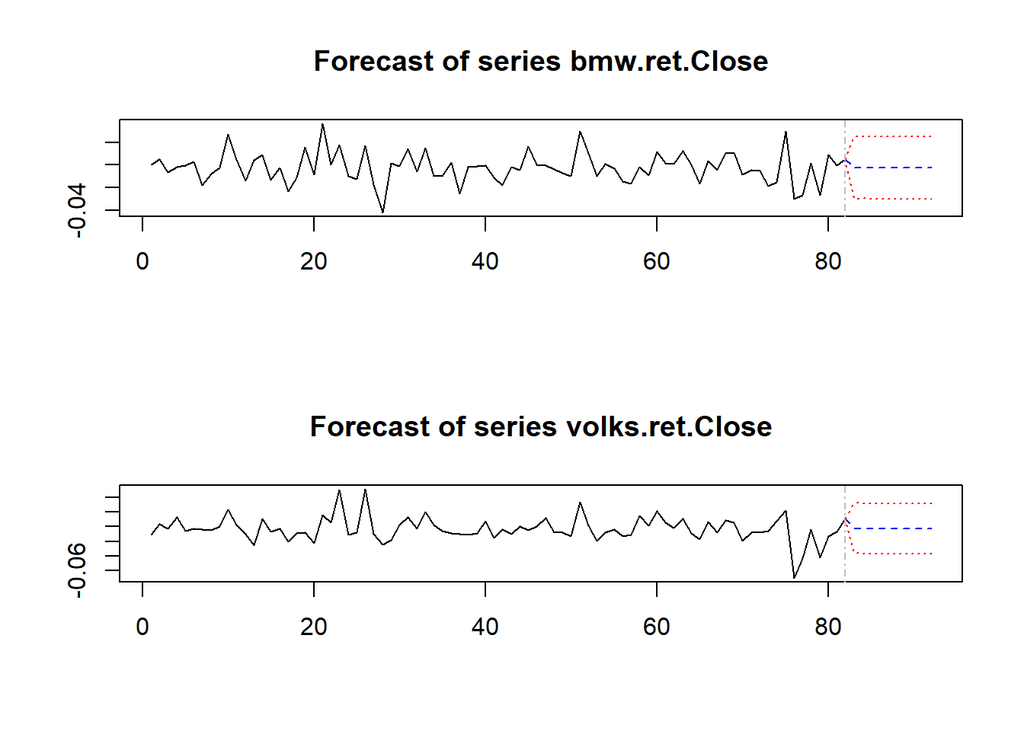

```r
plot(var.pred)
```

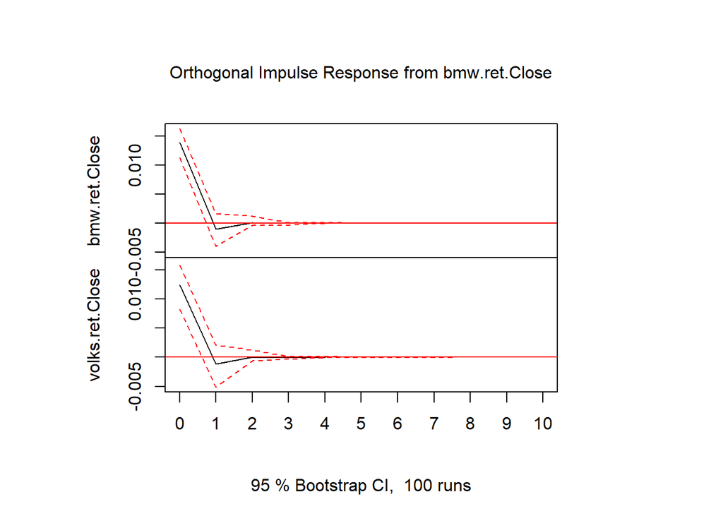

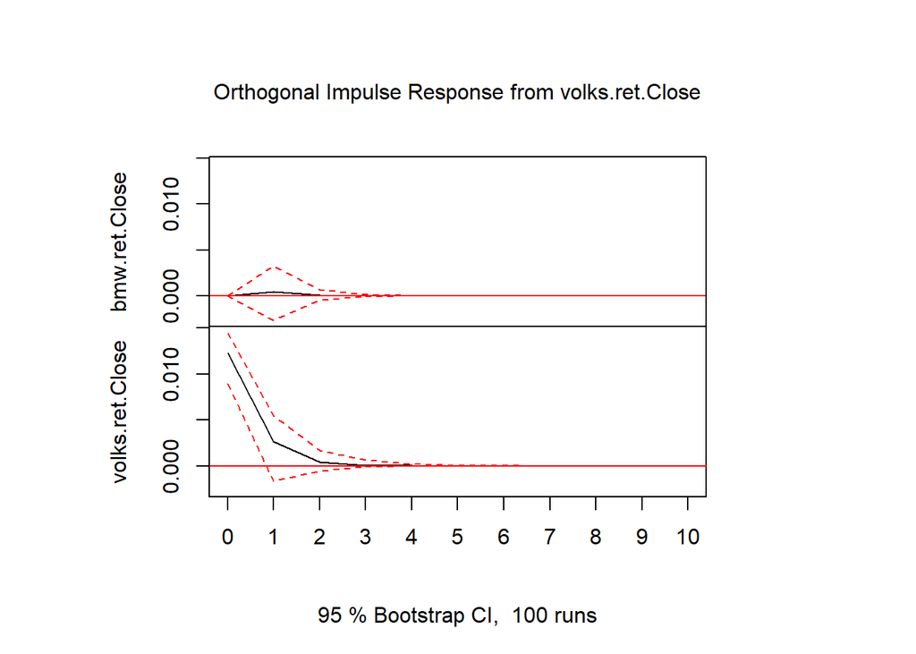

```r
var.irf <- irf(var)
plot(var.irf)
```